# report data analysis for cz data

Chiho Taniguchi

2023-02-26

# Data construction

We use data defining the market as commuting zone(cz) and restrict data to the general establishments only for analysis. After dropping establishments which have missing either of wage / fee / cz data and creating log transformed wage / fee, we create N_jt and dummy variables indicating the N_jt. N_jt and dummy variables are explained in detail later.

# Descriptive statistics

## wage (wage_{it})

```
##    Min. 1st Qu.  Median    Mean 3rd Qu.    Max.
##  0.5410  0.8396  0.9507  0.9728  1.0596  3.8674
```

## fee (fee_{it})

```
##    Min. 1st Qu.  Median    Mean 3rd Qu.    Max.
##   0.680   1.204   1.367   1.457   1.563  35.738
```

## N_jt

N_jt is a variable that indicates the number of general establishments present in commuting zone(j) in year t.

|  | N_jt |
| --- | --- |
| 10% | 21.2 |
| 25% | 51.5 |
| 50% | 106.0 |
| 75% | 192.5 |
| 100% | 3847.0 |

### Show historgam

On the left is the distribution of N_jt, without duplicates, and on the right is the distribution of N_jt, using all data (allowing duplicates).

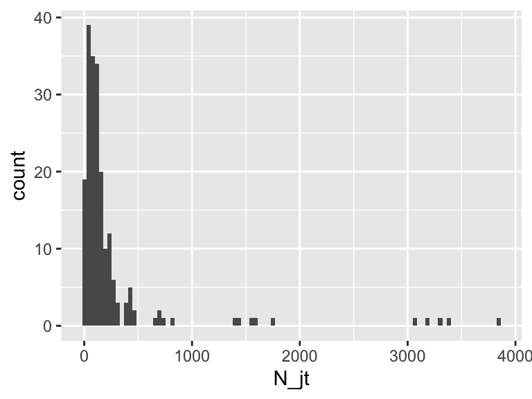

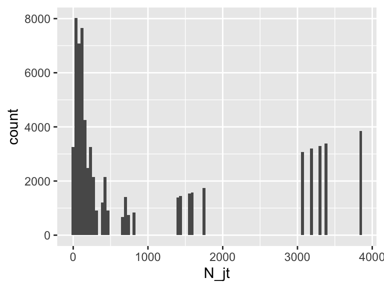

# Analyze different N_jt

Analyze the impact of the number of general establishments in each market (cz) on the log transformed wage / fee:

$$

Y_{ijt} = N_{jt} + c_{j} + c_{t} + u_{ijt},\ Y_{ijt} = N_{jt} + c_{i} + c_{t} + u_{ijt},\ Y_{ijt} = N_{jt} + c_{j} + c_{i} + c_{t} + u_{ijt}.

$$

$i$: Establishment, $j$: Commuting zone, $t$: Year  
$Y_{ijt}$: $\log{(wage_{ijt})}$, $\log{(fee_{ijt})}$

We also analyze N_jt is divided by the number after N_jt.

## Analyze for N_jt

|  | log(fee) | log(fee) | log(fee) | log(wage) | log(wage) | log(wage) |
| --- | --- | --- | --- | --- | --- | --- |
| N_jt | 0.000 | 0.000*** | 0.000 | 0.000 | 0.000*** | 0.000 |
|  | [0.000, 0.000] | [0.000, 0.000] | [0.000, 0.000] | [0.000, 0.000] | [0.000, 0.000] | [0.000, 0.000] |
| j_FE | Y | N | Y | Y | N | Y |
| t_FE | Y | Y | Y | Y | Y | Y |
| i_FE | N | Y | Y | N | Y | Y |
| Num.Obs. | 71486 | 71484 | 71484 | 71486 | 71484 | 71484 |
| R2 | 0.184 | 0.527 | 0.570 | 0.209 | 0.534 | 0.580 |
| R2 Adj. | 0.182 | 0.483 | 0.528 | 0.207 | 0.490 | 0.538 |
| RMSE | 0.35 | 0.27 | 0.26 | 0.31 | 0.24 | 0.23 |

+ p < 0.1, * p < 0.05, ** p < 0.01, *** p < 0.001

## Analyze for N_jt_10

|  | log(fee) | log(fee) | log(fee) | log(wage) | log(wage) | log(wage) |
| --- | --- | --- | --- | --- | --- | --- |
| N_jt_10 | 0.000 | 0.001*** | 0.000 | 0.000 | 0.001*** | 0.000 |
|  | [0.000, 0.000] | [0.001, 0.001] | [0.000, 0.000] | [0.000, 0.000] | [0.001, 0.001] | [0.000, 0.000] |
| j_FE | Y | N | Y | Y | N | Y |
| t_FE | Y | Y | Y | Y | Y | Y |
| i_FE | N | Y | Y | N | Y | Y |
| Num.Obs. | 71486 | 71484 | 71484 | 71486 | 71484 | 71484 |
| R2 | 0.184 | 0.527 | 0.570 | 0.209 | 0.534 | 0.580 |
| R2 Adj. | 0.182 | 0.483 | 0.528 | 0.207 | 0.490 | 0.538 |
| RMSE | 0.35 | 0.27 | 0.26 | 0.31 | 0.24 | 0.23 |

+ p < 0.1, * p < 0.05, ** p < 0.01, *** p < 0.001

## Analyze for N_jt_100

|  | log(fee) | log(fee) | log(fee) | log(wage) | log(wage) | log(wage) |
| --- | --- | --- | --- | --- | --- | --- |
| N_jt_100 | −0.001 | 0.007*** | 0.000 | −0.001 | 0.007*** | 0.000 |
|  | [−0.003, 0.001] | [0.007, 0.007] | [−0.002, 0.002] | [−0.003, 0.001] | [0.007, 0.007] | [−0.002, 0.002] |
| j_FE | Y | N | Y | Y | N | Y |
| t_FE | Y | Y | Y | Y | Y | Y |
| i_FE | N | Y | Y | N | Y | Y |
| Num.Obs. | 71486 | 71484 | 71484 | 71486 | 71484 | 71484 |
| R2 | 0.184 | 0.527 | 0.570 | 0.209 | 0.534 | 0.580 |
| R2 Adj. | 0.182 | 0.483 | 0.528 | 0.207 | 0.490 | 0.538 |
| RMSE | 0.35 | 0.27 | 0.26 | 0.31 | 0.24 | 0.23 |

+ p < 0.1, * p < 0.05, ** p < 0.01, *** p < 0.001

## Analyze for N_jt_1000

|  | log(fee) | log(fee) | log(fee) | log(wage) | log(wage) | log(wage) |
| --- | --- | --- | --- | --- | --- | --- |
| N_jt_1000 | −0.012 | 0.070*** | 0.002 | −0.010 | 0.069*** | 0.000 |
|  | [−0.035, 0.012] | [0.068, 0.073] | [−0.017, 0.021] | [−0.031, 0.011] | [0.067, 0.071] | [−0.017, 0.017] |
| j_FE | Y | N | Y | Y | N | Y |
| t_FE | Y | Y | Y | Y | Y | Y |
| i_FE | N | Y | Y | N | Y | Y |
| Num.Obs. | 71486 | 71484 | 71484 | 71486 | 71484 | 71484 |
| R2 | 0.184 | 0.527 | 0.570 | 0.209 | 0.534 | 0.580 |
| R2 Adj. | 0.182 | 0.483 | 0.528 | 0.207 | 0.490 | 0.538 |
| RMSE | 0.35 | 0.27 | 0.26 | 0.31 | 0.24 | 0.23 |

+ p < 0.1, * p < 0.05, ** p < 0.01, *** p < 0.001

## Analyze for N_jt_10000

|  | log(fee) | log(fee) | log(fee) | log(wage) | log(wage) | log(wage) |
| --- | --- | --- | --- | --- | --- | --- |
| N_jt_10000 | −0.116 | 0.703*** | 0.018 | −0.102 | 0.691*** | −0.003 |
|  | [−0.350, 0.119] | [0.679, 0.727] | [−0.171, 0.207] | [−0.309, 0.105] | [0.670, 0.712] | [−0.171, 0.165] |
| j_FE | Y | N | Y | Y | N | Y |
| t_FE | Y | Y | Y | Y | Y | Y |
| i_FE | N | Y | Y | N | Y | Y |
| Num.Obs. | 71486 | 71484 | 71484 | 71486 | 71484 | 71484 |
| R2 | 0.184 | 0.527 | 0.570 | 0.209 | 0.534 | 0.580 |
| R2 Adj. | 0.182 | 0.483 | 0.528 | 0.207 | 0.490 | 0.538 |
| RMSE | 0.35 | 0.27 | 0.26 | 0.31 | 0.24 | 0.23 |

+ p < 0.1, * p < 0.05, ** p < 0.01, *** p < 0.001

## Analyze for N_jt_100000

|  | log(fee) | log(fee) | log(fee) | log(wage) | log(wage) | log(wage) |
| --- | --- | --- | --- | --- | --- | --- |
| N_jt_100000 | −1.155 | 7.029*** | 0.180 | −1.019 | 6.908*** | −0.027 |
|  | [−3.497, 1.187] | [6.792, 7.266] | [−1.709, 2.068] | [−3.093, 1.055] | [6.696, 7.120] | [−1.707, 1.653] |
| j_FE | Y | N | Y | Y | N | Y |
| t_FE | Y | Y | Y | Y | Y | Y |
| i_FE | N | Y | Y | N | Y | Y |
| Num.Obs. | 71486 | 71484 | 71484 | 71486 | 71484 | 71484 |
| R2 | 0.184 | 0.527 | 0.570 | 0.209 | 0.534 | 0.580 |
| R2 Adj. | 0.182 | 0.483 | 0.528 | 0.207 | 0.490 | 0.538 |
| RMSE | 0.35 | 0.27 | 0.26 | 0.31 | 0.24 | 0.23 |

+ p < 0.1, * p < 0.05, ** p < 0.01, *** p < 0.001

# Analyze for N_jt with categorical dummy variables

Analyze the impact of the marginally increase in the number of general establishments in each market (cz) on the log transformed wage / fee:

$$

$$

$i$: Establishment, $j$: Commuting zone, $t$: Year  
$Y_{ijt}$: $\log{(wage_{ijt})}$, $\log{(fee_{ijt})}$

## Categorical variables per quantile (20)

We create categorical dummy variables as follows.

D_20 : Dummy variable that takes 1 when N_jt is less than the 20th percentile value  
D_40 : Dummy variable that takes 1 when N_jt is greater than or equal to the 20th percentile value and less than or equal to the 40th percentile value  
D_60 : Dummy variable that takes 1 when N_jt is greater than the 40th percentile value and less than the 60th percentile value  
D_80 : Dummy variable that takes 1 when N_jt is above the 60th percentile value and below the 80th percentile value  
D_100 : Dummy variable that takes 1 when N_jt is greater than or equal to the 80th percentile value

|  | log(fee) | log(fee) | log(fee) | log(wage) | log(wage) | log(wage) |
| --- | --- | --- | --- | --- | --- | --- |
| D_40 | 0.019 | 0.051*** | 0.007 | 0.007 | 0.051*** | −0.005 |
|  | [−0.020, 0.058] | [0.042, 0.060] | [−0.023, 0.037] | [−0.028, 0.042] | [0.043, 0.060] | [−0.031, 0.022] |
| D_60 | 0.015 | 0.074*** | 0.005 | 0.004 | 0.077*** | −0.007 |
|  | [−0.031, 0.061] | [0.065, 0.083] | [−0.030, 0.041] | [−0.037, 0.045] | [0.069, 0.085] | [−0.038, 0.025] |
| D_80 | 0.025 | 0.137*** | 0.008 | 0.009 | 0.137*** | −0.008 |
|  | [−0.026, 0.077] | [0.130, 0.145] | [−0.032, 0.047] | [−0.036, 0.055] | [0.130, 0.144] | [−0.043, 0.027] |
| D_100 |  | 0.304*** |  |  | 0.300*** |  |
|  |  | [0.294, 0.314] |  |  | [0.291, 0.308] |  |
| j_FE | Y | N | Y | Y | N | Y |
| t_FE | Y | Y | Y | Y | Y | Y |
| i_FE | N | Y | Y | N | Y | Y |
| Num.Obs. | 71486 | 71484 | 71484 | 71486 | 71484 | 71484 |
| R2 | 0.184 | 0.533 | 0.570 | 0.209 | 0.540 | 0.580 |
| R2 Adj. | 0.182 | 0.488 | 0.528 | 0.207 | 0.497 | 0.538 |
| RMSE | 0.35 | 0.27 | 0.26 | 0.31 | 0.24 | 0.23 |

+ p < 0.1, * p < 0.05, ** p < 0.01, *** p < 0.001

## Categorical variables per quantile (10)

We create categorical dummy variables as follows.

D10 : Dummy variable that takes 1 when N_jt is less than the 10th percentile value  
D20 : Dummy variable that takes 1 when N_jt is greater than or equal to the 10th percentile value and less than the 20th percentile value  
D30 : Dummy variable that takes 1 when N_jt is greater than the 20th percentile value and less than the 30th percentile value  
D40 : Dummy variable that takes 1 when N_jt is above the 30th percentile value and below the 40th percentile value  
D50 : Dummy variable that takes 1 when N_jt is above the 40th percentile value and below the 50th percentile value  
D60 : Dummy variable that takes 1 when N_jt is above the 50th percentile value and below the 60th percentile value  
D70 : Dummy variable that takes 1 when N_jt is above the 60th percentile value and below the 70th percentile value  
D80 : Dummy variable that takes 1 when N_jt is above the 70th percentile value and below the 80th percentile value  
D90 : Dummy variable that takes 1 when N_jt is above the 80th percentile value and below the 90th percentile value  
D100 : Dummy variable that takes 1 when N_jt is greater than or equal to the 90th percentile value

|  | log(fee) | log(fee) | log(fee) | log(wage) | log(wage) | log(wage) |
| --- | --- | --- | --- | --- | --- | --- |
| D20 | −0.010 | 0.057*** | −0.011 | −0.012 | 0.042*** | −0.014 |
|  | [−0.050, 0.030] | [0.044, 0.070] | [−0.042, 0.020] | [−0.048, 0.023] | [0.031, 0.054] | [−0.041, 0.013] |
| D30 | 0.009 | 0.079*** | −0.003 | −0.005 | 0.068*** | −0.018 |
|  | [−0.047, 0.065] | [0.066, 0.093] | [−0.047, 0.040] | [−0.055, 0.045] | [0.056, 0.080] | [−0.057, 0.020] |
| D40 | 0.023 | 0.086*** | 0.004 | 0.012 | 0.082*** | −0.006 |
|  | [−0.042, 0.087] | [0.072, 0.099] | [−0.046, 0.053] | [−0.045, 0.069] | [0.070, 0.094] | [−0.050, 0.038] |
| D50 | 0.019 | 0.097*** | 0.002 | 0.010 | 0.096*** | −0.008 |
|  | [−0.050, 0.089] | [0.084, 0.111] | [−0.051, 0.055] | [−0.052, 0.071] | [0.084, 0.108] | [−0.055, 0.039] |
| D60 | 0.016 | 0.111*** | −0.002 | 0.009 | 0.102*** | −0.010 |
|  | [−0.060, 0.092] | [0.098, 0.124] | [−0.060, 0.057] | [−0.059, 0.076] | [0.091, 0.113] | [−0.062, 0.042] |
| D70 | 0.027 | 0.116*** | 0.001 | 0.014 | 0.104*** | −0.013 |
|  | [−0.052, 0.107] | [0.103, 0.129] | [−0.060, 0.062] | [−0.057, 0.084] | [0.092, 0.115] | [−0.067, 0.042] |
| D80 | 0.030 | 0.185*** | 0.008 | 0.024 | 0.178*** | 0.004 |
|  | [−0.055, 0.115] | [0.172, 0.198] | [−0.058, 0.073] | [−0.051, 0.099] | [0.166, 0.189] | [−0.054, 0.062] |
| D90 | 0.034 | 0.155*** | 0.015 | 0.023 | 0.147*** | 0.006 |
|  | [−0.056, 0.123] | [0.142, 0.168] | [−0.054, 0.084] | [−0.056, 0.103] | [0.136, 0.158] | [−0.055, 0.067] |
| D100 | 0.044 | 0.260*** | 0.014 | 0.028 | 0.250*** | 0.000 |
|  | [−0.051, 0.138] | [0.248, 0.271] | [−0.059, 0.086] | [−0.055, 0.112] | [0.240, 0.260] | [−0.065, 0.064] |
| j_FE | Y | N | Y | Y | N | Y |
| t_FE | Y | Y | Y | Y | Y | Y |
| i_FE | N | Y | Y | N | Y | Y |
| Num.Obs. | 71486 | 71484 | 71484 | 71486 | 71484 | 71484 |
| R2 | 0.184 | 0.528 | 0.570 | 0.209 | 0.535 | 0.580 |
| R2 Adj. | 0.182 | 0.483 | 0.528 | 0.207 | 0.491 | 0.538 |
| RMSE | 0.35 | 0.27 | 0.26 | 0.31 | 0.24 | 0.23 |

+ p < 0.1, * p < 0.05, ** p < 0.01, *** p < 0.001

# Analyze using Bartik IV (bartik_cz_t)

$$

$$

$i$: Establishment, $j$: Commuting zone, $t$: Year  
$Y_{ijt}$: $\log{(wage_{ijt})}$, $\log{(fee_{ijt})}$

## 2nd stage

$$

$$

|  | log(fee) | log(wage) |
| --- | --- | --- |
| N_jt_1000(fit) | −0.076 | −0.049 |
|  | [−0.286, 0.135] | [−0.227, 0.129] |
| j_FE | Y | Y |
| t_FE | Y | Y |
| i_FE | N | N |
| Num.Obs. | 71486 | 71486 |
| R2 | 0.184 | 0.209 |
| R2 Adj. | 0.181 | 0.207 |
| RMSE | 0.35 | 0.31 |
| Std.Errors | by: cz | by: cz |

+ p < 0.1, * p < 0.05, ** p < 0.01, *** p < 0.001

## 1st stage

$$

$$

|  | N_jt_1000(1st stage cz) |
| --- | --- |
| bartik_cz_t | −0.910 |
|  | [−2.205, 0.386] |
| Num.Obs. | 71486 |
| R2 | 0.993 |
| R2 Adj. | 0.993 |
| AIC | −112455.9 |
| BIC | −110381.9 |
| RMSE | 0.11 |
| Std.Errors | by: cz |

+ p < 0.1, * p < 0.05, ** p < 0.01, *** p < 0.001

## reduced form

$$

$$

|  | log(fee) | log(wage) |
| --- | --- | --- |
| bartik_cz_t | 0.069 | 0.045 |
|  | [−0.174, 0.312] | [−0.171, 0.260] |
| j_FE | Y | Y |
| t_FE | Y | Y |
| i_FE | N | N |
| Num.Obs. | 71486 | 71486 |
| R2 | 0.184 | 0.209 |
| R2 Adj. | 0.182 | 0.207 |
| RMSE | 0.35 | 0.31 |

+ p < 0.1, * p < 0.05, ** p < 0.01, *** p < 0.001

# Analyze residuals for cz data

## Regress N_jt on commuting zone (cz) / year fixed effect

$$

$$

### Show histogram (unique)

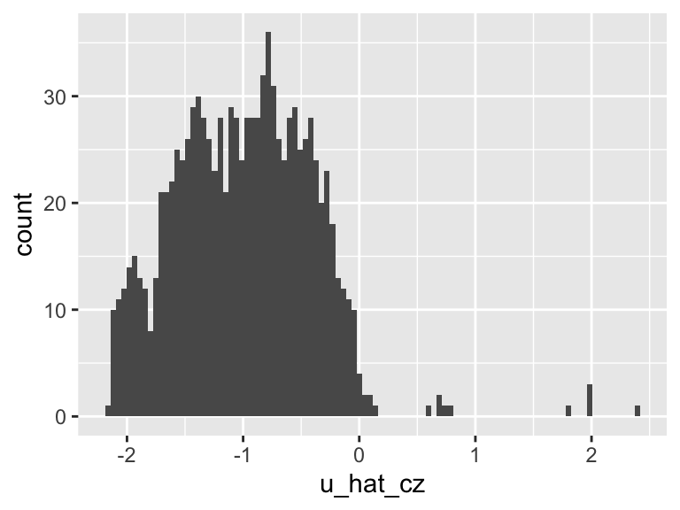

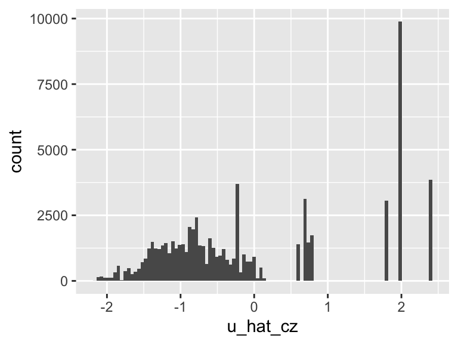

### Summary of the residuals

```
##     u_hat_cz
##  Min.   :-2.1578
##  1st Qu.:-1.4422
##  Median :-0.9894
##  Mean   :-1.0001
##  3rd Qu.:-0.5765
##  Max.   : 2.4056
```